# Moving Violations — Deliverable (HTML)

Isaac Nashagh

```r
library(tidyverse)
library(readxl)
library(janitor)
library(lubridate)
library(kableExtra)
library(leaflet)
```

Data:

```r
data_file <- "C:/Users/Isaac/OneDrive/Documents/Moving_Violations_Issued_in_October_2024.xlsx"

raw <- read_excel(data_file)
dat <- raw %>% janitor::clean_names()
```

```r
# convert all dates to a more usable format
possible_dates <- c("issue_date","issuedate","viol_date","violation_date","date","issue_dt")
for (nm in intersect(names(dat), possible_dates)) {
  dat[[nm]] <- suppressWarnings(lubridate::ymd_hms(dat[[nm]], quiet = TRUE))
  # Convert issue_time
if ("issue_time" %in% names(dat)) {
dat <- dat %>%
mutate(
issue_time_str = sprintf("%04d", issue_time),              # pad with zeros
issue_time_readable = suppressWarnings(lubridate::hm(paste0(substr(issue_time_str, 1, 2), ":", substr(issue_time_str, 3, 4))))
)
}

glimpse(dat$issue_time_readable)

  if (all(is.na(dat[[nm]]))) dat[[nm]] <- suppressWarnings(lubridate::ymd(dat[[nm]], quiet = TRUE))
}
```

```
Formal class 'Period' [package "lubridate"] with 6 slots
  ..@ .Data : num [1:266297] 0 0 0 0 0 0 0 0 0 0 ...
  ..@ year  : num [1:266297] 0 0 0 0 0 0 0 0 0 0 ...
  ..@ month : num [1:266297] 0 0 0 0 0 0 0 0 0 0 ...
  ..@ day   : num [1:266297] 0 0 0 0 0 0 0 0 0 0 ...
  ..@ hour  : num [1:266297] 16 16 17 17 18 18 15 20 20 5 ...
  ..@ minute: num [1:266297] 22 35 12 12 12 30 20 24 24 33 ...
```

```r
glimpse(dat)
```

```
Rows: 266,297
Columns: 31
$ objectid               <dbl> 40200459, 40200460, 40200461, 40200462, 4020046…
$ location               <chr> "BLOCK 200 WASHINGTON AVE SW", "100 BLK INDEPEN…
$ xcoord                 <dbl> 398811.1, 399591.5, 399210.5, 399210.5, 399823.…
$ ycoord                 <dbl> 135499.9, 135530.5, 134299.5, 134299.5, 134352.…
$ issue_date             <dttm> 2024-10-01 04:00:00, 2024-10-02 04:00:00, 2024…
$ issue_time             <dbl> 1622, 1635, 1712, 1712, 1812, 1830, 1520, 2024,…
$ issuing_agency_code    <dbl> 23, 23, 23, 23, 23, 23, 23, 23, 23, 23, 23, 23,…
$ issuing_agency_name    <chr> "UNITED STATES CAPITOL POLICE", "UNITED STATES …
$ issuing_agency_short   <chr> "USCP", "USCP", "USCP", "USCP", "USCP", "USCP",…
$ violation_code         <chr> "T113", "T404", "T711", "T333", "T018", "T404",…
$ violation_process_desc <chr> "FAIL TO STOP PER REGULATIONS FACING RED SIGNAL…
$ plate_state            <chr> "VA", "VA", "VA", "VA", "DC", "MD", "VA", NA, N…
$ accident_indicator     <chr> NA, NA, NA, NA, NA, NA, NA, "Y", "Y", NA, NA, N…
```

[output cut: 18 more lines]

```r
#labels columns as numerical, date, or
var_type <- function(x) {
if (is.numeric(x)) {
"numeric"
} else if (inherits(x, "Date") || inherits(x, "POSIXct") || inherits(x, "POSIXt")) {
"date/time"
} else {
"categorical/text"
}
}


data_dict <- tibble(
variable = names(dat),
type = purrr::map_chr(dat, var_type),
n_missing = purrr::map_int(dat, ~ sum(is.na(.x))),
n_unique = purrr::map_int(dat, ~ dplyr::n_distinct(.x, na.rm = TRUE)),
example_value = purrr::map_chr(dat, ~ {
ex <- .x[which(!is.na(.x))[1]]
if (length(ex) == 0) return("-")
as.character(ex)
}),
description = c(
# 1 objectid
"Unique ID for each record",
# 2 location
"Street address or block of the violation",
# 3 xcoord
"X coordinate (projected/DC grid)",
# 4 ycoord
"Y coordinate (projected/DC grid)",
# 5 issue_date
"Date/time when the violation was issued",
# 6 issue_time
"Time of day in HHMM format (e.g., 1622 = 4:22 PM)",
# 7 issuing_agency_code
"Numeric code for the issuing agency",
# 8 issuing_agency_name
"Full name of the issuing agency",
# 9 issuing_agency_short
"Abbreviation of the issuing agency",
# 10 violation_code
"Alphanumeric code for the violation",
# 11 violation_process_desc
"Text description of the violation type",
# 12 plate_state
"State that issued the vehicle’s license plate",
# 13 accident_indicator
"Indicator if an accident was involved (Y/N)",
# 14 disposition_code
"Numeric code for the case disposition",
# 15 disposition_type
"Text outcome/status (e.g., Paid, Other)",
# 16 disposition_date
"Date the disposition was finalized (if any)",
# 17 fine_amount
"Fine amount (USD)",
# 18 total_paid
"Total amount paid (USD)",
# 19 penalty_1
"Additional penalty amount 1 (USD)",
# 20 penalty_2
"Additional penalty amount 2 (USD)",
# 21 penalty_3
"Additional penalty amount 3 (USD)",
# 22 penalty_4
"Additional penalty amount 4 (USD)",
# 23 penalty_5
"Additional penalty amount 5 (USD)",
# 24 rp_mult_owner_no
"Related property/owner number",
# 25 body_style
"Vehicle body type (mostly missing in this dataset)",
# 26 latitude
"Geographic latitude of the location",
# 27 longitude
"Geographic longitude of the location",
# 28 mar_id
"Map Reference/parcel ID for spatial join",
# 29 gis_last_mod_dttm
"Date/time of last GIS modification",
# 30 issue_time_str
"Formatted issue time string (HHMM padded for readability)",
# 31 issue_time_readable
"Converted issue time as a proper time object"
)

)



data_dict %>%
kbl(caption = "Data Dictionary — with Descriptions") %>%
kable_classic(full_width = FALSE)
```

Data Dictionary — with Descriptions

| variable | type | n_missing | n_unique | example_value | description |
| --- | --- | --- | --- | --- | --- |
| objectid | numeric | 0 | 266297 | 40200459 | Unique ID for each record |
| location | categorical/text | 3 | 2595 | BLOCK 200 WASHINGTON AVE SW | Street address or block of the violation |
| xcoord | numeric | 1116 | 1518 | 398811.117 | X coordinate (projected/DC grid) |
| ycoord | numeric | 1116 | 1516 | 135499.9 | Y coordinate (projected/DC grid) |
| issue_date | date/time | 0 | 31 | 2024-10-01 04:00:00 | Date/time when the violation was issued |
| issue_time | numeric | 0 | 1441 | 1622 | Time of day in HHMM format (e.g., 1622 = 4:22 PM) |
| issuing_agency_code | numeric | 0 | 26 | 23 | Numeric code for the issuing agency |
| issuing_agency_name | categorical/text | 0 | 26 | UNITED STATES CAPITOL POLICE | Full name of the issuing agency |
| issuing_agency_short | categorical/text | 0 | 26 | USCP | Abbreviation of the issuing agency |
| violation_code | categorical/text | 0 | 151 | T113 | Alphanumeric code for the violation |
| violation_process_desc | categorical/text | 1 | 149 | FAIL TO STOP PER REGULATIONS FACING RED SIGNAL | Text description of the violation type |
| plate_state | categorical/text | 261815 | 42 | VA | State that issued the vehicle’s license plate |
| accident_indicator | categorical/text | 262914 | 2 | Y | Indicator if an accident was involved (Y/N) |
| disposition_code | numeric | 0 | 32 | 0 | Numeric code for the case disposition |
| disposition_type | categorical/text | 0 | 6 | Other | Text outcome/status (e.g., Paid, Other) |
| disposition_date | categorical/text | 264154 | 48 | 2024/10/24 04:00:00+00 | Date the disposition was finalized (if any) |
| fine_amount | numeric | 0 | 18 | 150 | Fine amount (USD) |
| total_paid | numeric | 0 | 32 | 150 | Total amount paid (USD) |
| penalty_1 | numeric | 0 | 16 | 0 | Additional penalty amount 1 (USD) |
| penalty_2 | numeric | 0 | 1 | 0 | Additional penalty amount 2 (USD) |
| penalty_3 | numeric | 0 | 1 | 0 | Additional penalty amount 3 (USD) |
| penalty_4 | numeric | 0 | 1 | 0 | Additional penalty amount 4 (USD) |
| penalty_5 | numeric | 0 | 1 | 0 | Additional penalty amount 5 (USD) |
| rp_mult_owner_no | numeric | 0 | 4631 | 0 | Related property/owner number |
| body_style | categorical/text | 266297 | 0 | NA | Vehicle body type (mostly missing in this dataset) |
| latitude | numeric | 1116 | 155 | 38.887 | Geographic latitude of the location |
| longitude | numeric | 1116 | 188 | -77.014 | Geographic longitude of the location |
| mar_id | numeric | 18361 | 1518 | 805923 | Map Reference/parcel ID for spatial join |
| gis_last_mod_dttm | categorical/text | 0 | 84 | 2024/11/16 15:02:29+00 | Date/time of last GIS modification |
| issue_time_str | categorical/text | 0 | 1441 | 1622 | Formatted issue time string (HHMM padded for readability) |
| issue_time_readable | numeric | 0 | 1441 | 16H 22M 0S | Converted issue time as a proper time object |

This dataset shows moving violations with categorical, numerical, and date fields. The table lists all the variables and shows the number of missing values, unique values, and an example row. Data Cleaning

Data cleaning steps included: Standardizing names with clean_names() Parsing dates/times using ymd_hms() and hm() Creating a readable issue time variable (issue_time_readable) Assessing each variable’s type (numeric, date/time, or categorical)

The dataset was tidy upon finding it.

```r
#summary for number variables
num_vars <- dat %>% select(where(is.numeric))
if (ncol(num_vars) > 0) {
summary(num_vars) %>%
kbl(caption="Summary statistics for numeric variables") %>%
kable_classic(full_width = FALSE)
} else {
cat("No numeric variables detected.\n")
}
```

Summary statistics for numeric variables

|  | objectid | xcoord | ycoord | issue_time | issuing_agency_code | disposition_code | fine_amount | total_paid | penalty_1 | penalty_2 | penalty_3 | penalty_4 | penalty_5 | rp_mult_owner_no | latitude | longitude | mar_id | issue_time_readable |
| --- | --- | --- | --- | --- | --- | --- | --- | --- | --- | --- | --- | --- | --- | --- | --- | --- | --- | --- |
|  | Min. :40200459 | Min. :390468 | Min. :128206 | Min. : 0 | Min. : 0.00 | Min. : 0.0000 | Min. : 0.0 | Min. : 0.00 | Min. : 0.00 | Min. :0 | Min. :0 | Min. :0 | Min. :0 | Min. : 0 | Min. :38.82 | Min. :-77.11 | Min. :-28474 | Min. :0S |
|  | 1st Qu.:40373026 | 1st Qu.:398559 | 1st Qu.:135529 | 1st Qu.: 856 | 1st Qu.:92.00 | 1st Qu.: 0.0000 | 1st Qu.: 100.0 | 1st Qu.: 0.00 | 1st Qu.: 0.00 | 1st Qu.:0 | 1st Qu.:0 | 1st Qu.:0 | 1st Qu.:0 | 1st Qu.: 0 | 1st Qu.:38.89 | 1st Qu.:-77.02 | 1st Qu.:804685 | 1st Qu.:8H 56M 0S |
|  | Median :40439600 | Median :400544 | Median :137264 | Median :1328 | Median :92.00 | Median : 0.0000 | Median : 100.0 | Median : 0.00 | Median : 0.00 | Median :0 | Median :0 | Median :0 | Median :0 | Median : 0 | Median :38.90 | Median :-76.99 | Median :811375 | Median :13H 28M 0S |
|  | Mean :40433290 | Mean :400380 | Mean :137145 | Mean :1289 | Mean :90.65 | Mean : 0.3503 | Mean : 117.5 | Mean : 33.46 | Mean : 24.44 | Mean :0 | Mean :0 | Mean :0 | Mean :0 | Mean : 24084907 | Mean :38.90 | Mean :-77.00 | Mean :820031 | Mean :13H 5M 22.9268823907114S |
|  | 3rd Qu.:40509379 | 3rd Qu.:402604 | 3rd Qu.:138829 | 3rd Qu.:1745 | 3rd Qu.:92.00 | 3rd Qu.: 0.0000 | 3rd Qu.: 100.0 | 3rd Qu.: 100.00 | 3rd Qu.: 0.00 | 3rd Qu.:0 | 3rd Qu.:0 | 3rd Qu.:0 | 3rd Qu.:0 | 3rd Qu.: 0 | 3rd Qu.:38.92 | 3rd Qu.:-76.97 | 3rd Qu.:900262 | 3rd Qu.:17H 45M 0S |
|  | Max. :40698951 | Max. :407708 | Max. :146652 | Max. :2359 | Max. :92.00 | Max. :146.0000 | Max. :5000.0 | Max. :1100.00 | Max. :1000.00 | Max. :0 | Max. :0 | Max. :0 | Max. :0 | Max. :950723810 | Max. :38.99 | Max. :-76.91 | Max. :914269 | Max. :23H 59M 0S |
|  | NA | NA's :1116 | NA's :1116 | NA | NA | NA | NA | NA | NA | NA | NA | NA | NA | NA | NA's :1116 | NA's :1116 | NA's :18361 | NA |

```r
NA
```

This summary table shows the characteristics of the numeric columns. Most variables show realistic values, although fines and penalties have much higher means than medians, indicating outliers.

Exploratory Data Analysis:

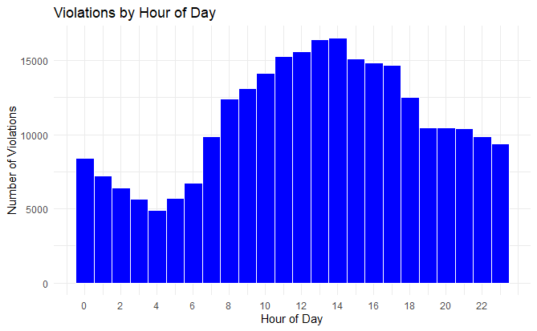

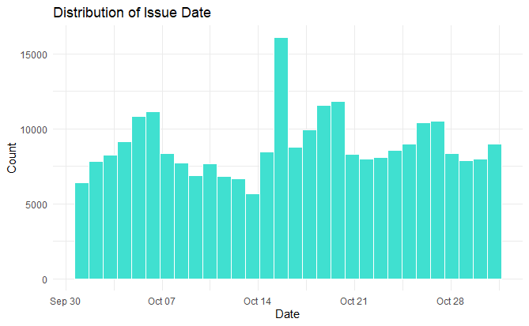

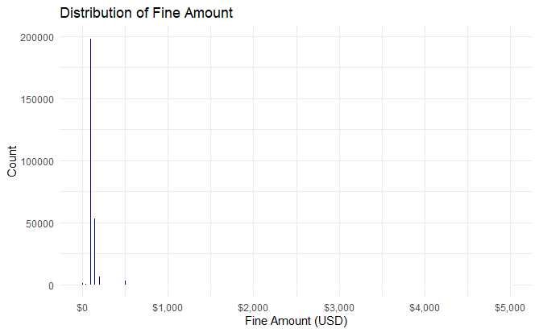

```r
clean_title <- function(x) {
  x <- gsub("_", " ", x)
  x <- tools::toTitleCase(x)
  return(x)
}


hist_vars <- c("issue_time_readable", "issue_date", "fine_amount")
selected_vars <- hist_vars[hist_vars %in% names(dat)]

for (v in selected_vars) {

  # Hour
  if (v == "issue_time_readable" && "issue_time_readable" %in% names(dat)) {
    dat %>%
      filter(!is.na(issue_time_readable)) %>%
      mutate(hour = lubridate::hour(issue_time_readable)) %>%
      ggplot(aes(x = hour)) +
      geom_histogram(binwidth = 1, fill = "blue", color = "white") +
      scale_x_continuous(breaks = seq(0, 23, 2)) +
      labs(
        title = "Violations by Hour of Day",
        x = "Hour of Day",
        y = "Number of Violations"
      ) +
      theme_minimal() -> p
    print(p)
  }

  # Issue date
  else if (inherits(dat[[v]], "POSIXct") || inherits(dat[[v]], "Date")) {
    ggplot(dat, aes(x = !!sym(v))) +
      geom_histogram(bins = 30, fill = "turquoise", color = "white") +
      labs(
        title = paste("Distribution of", clean_title(v)),
        x = "Date",
        y = "Count"
      ) +
      theme_minimal() -> p
    print(p)
  }

  # Fine
  else if (v == "fine_amount" && is.numeric(dat[[v]])) {
    ggplot(dat, aes(x = fine_amount)) +
      geom_histogram(binwidth = 20, fill = "navy", color = "white") +
      scale_x_continuous(labels = scales::dollar_format()) +
      labs(
        title = "Distribution of Fine Amount",
        x = "Fine Amount (USD)",
        y = "Count"
      ) +
      theme_minimal() -> p
    print(p)
  }
}
```

```r
NA
NA
NA
NA
```

Hours of Day: This histogram shows the distribution of moving violations across different hours of the day. Violations heavily increase around 6:00 AM and peak during typical daytime/early evening hours (9-5), and remain relatively high until around 8PM. After midnight, violations decrease steadily, reaching the lowest level at 4AM. This reflects common traffic patterns but also may suggest that ticketing agencies slow operations late at night.

Issue Date: The distribution of issue dates indicates that moving violations were issued consistently throughout October 2024. There are no significant gaps or irregularities in the daily counts. The peak on October 16th may be attributed to Ethel Kennedy’s memorial service, as the city released announcements warning of increased traffic on this day. This consistency supports the reliability of the dataset and indicates that the volume of violations was not influenced by outages, reporting delays, or many large events that might otherwise distort daily totals.

Fine Amount: The fine amounts have a strongly right-skewed distribution as the majority of citations are lower values with a right skewed tail of heavier penalties. Most violations appear to carry relatively small fines from standard traffic infractions, while the higher minority is from more serious offenses, namely speeding 20MPH over the limit. This skew explains the large gap between the mean and median reported in the summary statistics.

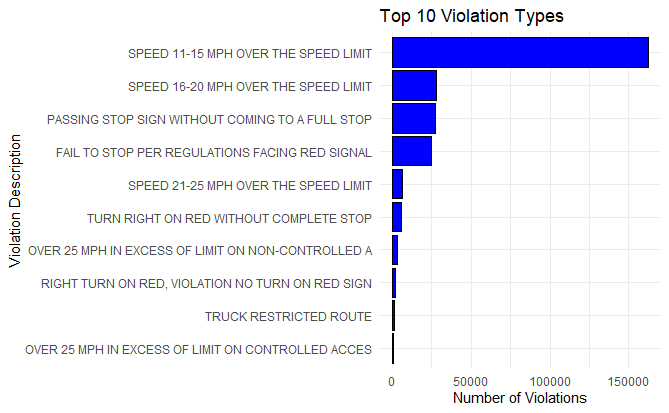

```r
# Top issuing agencies and violation types
if ("issuing_agency_name" %in% names(dat) & "violation_process_desc" %in% names(dat)) {

  # Top 10 agencies
  top_agencies <- dat %>%
    count(issuing_agency_name, sort = TRUE) %>%
    slice_head(n = 10)

  ggplot(top_agencies, aes(x = reorder(issuing_agency_name, n), y = n)) +
    geom_col(fill = "orange", color = "black") +
    coord_flip() +
    labs(
      title = "Top 10 Issuing Agencies",
      x = "Agency Name",
      y = "Number of Violations"
    ) +
    theme_minimal()

  # Top 10 violation types
  top_violations <- dat %>%
    count(violation_process_desc, sort = TRUE) %>%
    slice_head(n = 10)

  ggplot(top_violations, aes(x = reorder(violation_process_desc, n), y = n)) +
    geom_col(fill = "blue", color = "black") +
    coord_flip() +
    labs(
      title = "Top 10 Violation Types",
      x = "Violation Description",
      y = "Number of Violations"
    ) +
    theme_minimal()
}
```

This graph shows the most frequent violation types. It is headed by moderate speeding (11-15mph over the speed limit). This suggests that speeding enforcement is likely a primary focus of traffic control in D.C. and that other infractions are much less common as this category has more violations than every other category combined. The top 4 violations make up more than 90% of all violations recorded.

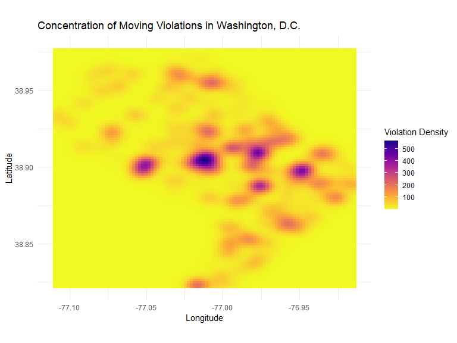

```r
map_data <- dat %>%
  filter(!is.na(latitude), !is.na(longitude))


if (nrow(map_data) > 20000) {
  map_data <- sample_n(map_data, 20000)
}

ggplot(map_data, aes(x = longitude, y = latitude)) +
  stat_density_2d(aes(fill = ..density..), geom = "raster", contour = FALSE) +
  scale_fill_viridis_c(option = "C", direction = -1) +
  labs(
    title = "Concentration of Moving Violations in Washington, D.C.",
    x = "Longitude",
    y = "Latitude",
    fill = "Violation Density"
  ) +
  coord_fixed() +
  theme_minimal()
```

```r
NA
NA
```

```r
#Find Missing data and arrange it
missing_tbl <- tibble(
variable = names(dat),
missing = map_int(dat, ~ sum(is.na(.x))),
percent_missing = round(map_dbl(dat, ~ mean(is.na(.x)) * 100), 2)
)

missing_tbl %>%
arrange(desc(percent_missing)) %>%
kbl(caption = "Missing Value Summary") %>%
kable_classic(full_width = FALSE)
```

Missing Value Summary

| variable | missing | percent_missing |
| --- | --- | --- |
| body_style | 266297 | 100.00 |
| disposition_date | 264154 | 99.20 |
| accident_indicator | 262914 | 98.73 |
| plate_state | 261815 | 98.32 |
| mar_id | 18361 | 6.89 |
| xcoord | 1116 | 0.42 |
| ycoord | 1116 | 0.42 |
| latitude | 1116 | 0.42 |
| longitude | 1116 | 0.42 |
| objectid | 0 | 0.00 |
| location | 3 | 0.00 |
| issue_date | 0 | 0.00 |
| issue_time | 0 | 0.00 |
| issuing_agency_code | 0 | 0.00 |
| issuing_agency_name | 0 | 0.00 |
| issuing_agency_short | 0 | 0.00 |
| violation_code | 0 | 0.00 |
| violation_process_desc | 1 | 0.00 |
| disposition_code | 0 | 0.00 |
| disposition_type | 0 | 0.00 |
| fine_amount | 0 | 0.00 |
| total_paid | 0 | 0.00 |
| penalty_1 | 0 | 0.00 |
| penalty_2 | 0 | 0.00 |
| penalty_3 | 0 | 0.00 |
| penalty_4 | 0 | 0.00 |
| penalty_5 | 0 | 0.00 |
| rp_mult_owner_no | 0 | 0.00 |
| gis_last_mod_dttm | 0 | 0.00 |
| issue_time_str | 0 | 0.00 |
| issue_time_readable | 0 | 0.00 |

This table shows the amount of missing values in the variables. A high percentage would likely disqualify a variable from being used to make inferences and a moderate percentage would warrant caution. The variables with missing data include body type and disposition date; both are optional in reports, meaning the missing variables in no way impacts the reliability of this dataset.

```r
# Check for outliers using IQR and ignores non-numeric types
num_vars <- dat %>%
  select(where(is.numeric))

if (ncol(num_vars) > 0) {
  outliers <- map_dfr(names(num_vars), function(v) {
    x <- num_vars[[v]]
    x <- x[!is.na(x)]

    # Skip columns with too few unique values
    if (length(unique(x)) < 4) return(tibble(variable = v, outliers = 0))

    # IQR method
    q1 <- quantile(x, 0.25)
    q3 <- quantile(x, 0.75)
    iqr <- q3 - q1
    low <- q1 - 1.5 * iqr
    high <- q3 + 1.5 * iqr

    tibble(variable = v, outliers = sum(x < low | x > high))
  })

  outliers %>%
    arrange(desc(outliers)) %>%
    kbl(caption = "Potential Outliers by Variable") %>%
    kable_classic(full_width = FALSE)
} else {
  cat("No numeric variables found for outlier detection.\n")
}
```

Potential Outliers by Variable

| variable | outliers |
| --- | --- |
| fine_amount | 68112 |
| penalty_1 | 54556 |
| latitude | 21603 |
| ycoord | 17337 |
| rp_mult_owner_no | 8785 |
| mar_id | 6608 |
| xcoord | 4553 |
| longitude | 4542 |
| issuing_agency_code | 4472 |
| disposition_code | 2143 |
| total_paid | 631 |
| objectid | 0 |
| issue_time | 0 |
| penalty_2 | 0 |
| penalty_3 | 0 |
| penalty_4 | 0 |
| penalty_5 | 0 |
| issue_time_readable | 0 |

```r
NA
NA
```

This shows the outliers in the dataset. Having this information clearly presented more easily allows me to identify what causes things like the right - skew of the fines in the dataset.

Full Report:

Libraries Used:

tidyverse – data manipulation and plotting readxl – importing the Excel dataset janitor – consistent variable name cleaning lubridate – parsing and handling dates/times kableExtra – formatting summary tables

Purpose:

The goal of this project is to analyze the moving violations issued in Washington, D.C. during October 2024 and understand the factors that influence where and when violations occur. This includes identifying:

-When during the day violations are most common -Which agencies issue the most citations -The most frequently issued violation types -How fines and penalties are distributed -Where violations cluster geographically -Determine if this is influeced by the presence of Federal buildings or police stations

Results:

The analysis uses descriptive statistics and data visualizations to uncover trends in time, location, fine amounts, and enforcement type. Histograms were used to explore continuous variables, bar charts for categorical rankings, and geospatial density plots to visualize location-based patterns.

Limitations:

Only includes a single month No speed-limit data provided

Future Work:

-Map violations by ward or neighborhood -Include D.C. boundary shapefiles for improved mapping -Explore relationships between violation type and time of day -Define specific School and Construction zone violations in data

Summary: